# Hypothesis Testing—Innocent Until

# Foundational Concepts

Hypothesis testing is one of the workhorses of statistical inference. The goal of this lecture is crystal clear: to illustrate and explain the logic of hypothesis testing. Basically, that’s the core of the idea of statistical inference in general.

```r
if (!caracas::has_sympy()) {
  caracas::install_sympy()
}
library(caracas);
library(sets)
library(tibble)
library(ggplot2)
library(dplyr)
```

```r
def_sym("X", "Y")

cmStats <- modules::use("CmStats.R")$cmStats;
```

Hypothesis testing is one of the most common statistical techniques used in education, psychology, social sciences, natural sciences, medicine, law, and every area to which statistics is applied.

We’ll rst describe how hypothesis testing works in an example. Our null hypothesis is that if we spin a penny, it has a .5 probability of landing heads up. At the end of the whole hypothesis testing process, the crux of the decision of whether to reject the null hypothesis or not depends on quantifying how rare different possible outcomes of the experiment are.

Thus, we need to investigate the possible outcomes of the coin experiment and how likely or unlikely each possible outcome is. We will spin the penny 100 times.

```r
coins <- sample(c("T", "H"), size=100, replace = TRUE)

cmStats$P(table(coins), 100)
```

```
coins
   H    T
0.55 0.45
```

```r
coins_df = tibble(flips = coins)
```

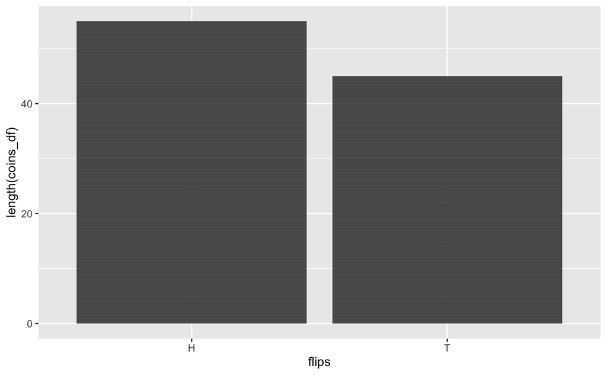

```r
ggplot( coins_df, aes(y = length(coins_df), x = flips)) +
  geom_col()
```

Next, we do the experiment and analyze the results. We spin the coin 100 times.

```r
coins_df = tibble(flips = sample(c("T", "H"), size=100, replace = TRUE))
```

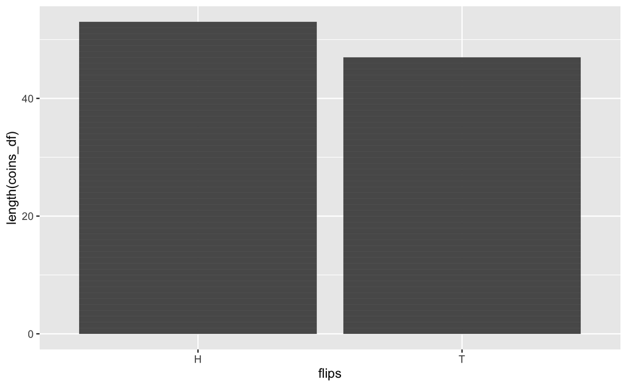

```r
ggplot( coins_df, aes(y = length(coins_df), x = flips)) +
  geom_col()
```

```r
count_table = table(coins_df)
count_table
```

```
flips
 H  T
53 47
```

```r
cmStats$P(count_table, 95)
```

```
flips
        H         T
0.5578947 0.4947368
```

```r
t.test(count_table)# not realy correct for the text below.
```

```
    One Sample t-test

data:  count_table
t = 16.667, df = 1, p-value = 0.03815
alternative hypothesis: true mean is not equal to 0
95 percent confidence interval:
 11.88139 88.11861
sample estimates:
mean of x
       50
```

Another example of hypothesis testing occurs if we are trying to determine whether or not a particular medication works by giving some people the medication and some a placebo and seeing whether there is a signi cant difference in the number who recover. For our experiment, we’ll take 100 people, all with athlete’s foot, and have them use the medication for a week. After the week, we count how many people are free from athlete’s foot.

Assume that we know that 40% of the time, a person’s athlete’s foot will disappear in a week without any medication. Thus, our null hypothesis is that each person has a 40% probability of cure with or without the medication (i.e., the medication has no effect). We’ll take as the alternative hypothesis that the probability of cure for people using the medication is different from 40%. We also decide how extreme a result of the experiment will have to be for us to reject the null hypothesis.

```r
p_value = 0.05
prob_null = 0.40
```

Our required signi cance level is 0.05, meaning that if the results of the experiment are so extreme that under the assumption of the null hypothesis, only 5 out of 100 experiments would yield a result that extreme or more extreme, we will reject the null hypothesis.

```r
p_value ~ cmStats$P(5, 100)
```

```
p_value ~ cmStats$P(5, 100)
```

```r
cmStats$P(5, 100)
```

```
[1] 0.05
```

In other words, if the p value is less than the signi cance level, we will reject the null hypothesis. We call such a result statistically signi cant. In the eld of statistics, signi cant does not mean “important.” Rather, it simply means that the signi cant item or event signi es something.

```r
free_foot = 51
```

Suppose that 51 of the 100 people who used the medication are free from athlete’s foot. In this case, the calculation gives the p value of

```r
(free_foot/100) - (prob_null / 2) + 0.01
```

```
[1] 0.32
```

As another example, consider the question of whether the typical American male adult consumes an average of 2400 calories each day. We ask 25 American adult males, and they average 2500.

```r
people = 25
avg_cal = 2400
reported_cal = 2500
std_cal = 270
```

Unlike the previous examples, knowing just the sample mean is not enough information. We also need to know something about how spread out the population’s eating habits are, that is, the standard deviation of the population. If there is a huge variation from person to person in number of calories consumed, then the difference between the sample mean of 2500 and the null hypothesis of 2400 is not as signi cant. The sample responses themselves give some information about the standard deviation of the population. Let’s suppose that the sample standard deviation (i.e., the spread in the 25 responses) is 270 calories.

```r
mans_cal_2400 = rnorm(1:people, mean = avg_cal)
mans_cal_2500 = rnorm(1:people, mean = reported_cal, sd = std_cal)
```

```r
t.test(mans_cal_2500, mu = reported_cal) # this conclusion needs to be review!
```

```
    One Sample t-test

data:  mans_cal_2500
t = -0.7625, df = 24, p-value = 0.4532
alternative hypothesis: true mean is not equal to 2500
95 percent confidence interval:
 2324.374 2580.866
sample estimates:
mean of x
  2452.62
```

State a hypothesis about the way the world is. The hypothesis is called the null hypothesis and is often the opposite of what we actually think might be true.

• State an alternative hypothesis. In the case where the null hypothesis is that the probability of something is a certain value, three standard possible alternative hypotheses exist:

• The probability is different from the value stated in the null hypothesis.

• The probability is greater than the value stated in the null hypothesis.

• The probability is less than the value stated in the null hypothesis.

• Declare what level of signi cance we require to reject the null hypothesis.

• Do the experiment, gather the results, and compute the probability that, under the assumption of the null hypothesis, the results would be as extreme as (or more extreme than) the result we actually obtained. This gives a p value.

• If the result is rare (p value smaller than our required level of signi cance), then we assert that the results are statistically signi cant, and we reject the null hypothesis:

• Rejecting the null hypothesis means concluding that it is false.

• Rejecting the null hypothesis also means concluding that the alternative hypothesis is true.

• If the result is not rare (p value larger than our required level of signi cance), then we do not reject the null hypothesis. # Concept and Applications

## INTERVAL ESTIMATES AND CONFIDENCE INTERVALS

When we calculate a point estimate, our chances of hitting the target population parameter are not very likely. We’ll often get close but will seldom hit the mark. In this lecture, you will learn about confidence intervals, with which we can increase our chances of capturing the true population parameter.

### CONFIDENCE INTERVALS

A confidence interval draws inferences about a population by estimating the value of an unknown parameter using an interval. We’re looking for an interval that covers the true population parameter with some amount of certainty or confidence.

But the problem is that a different random sample ( with different observed values ) would yield different estimates for μ. Which of those estimates ( the sample mean from our first sample or the sample mean from our second sample ) would be closest to the true value? We’d really have no way of knowing.

To create a confidence interval, we start with the point estimate ± estimation error. If our interval is narrow, that means that our estimate is precise.

Let X1, X2, … X𝑛 be a random sample from a normal distribution with μ and σ. We know that regardless of sample size 𝑛, X is normally distributed with expected value μ and standard deviation . We get this from the central limit theorem.

```r
cmStats$Z_score_sym(X)
```

```
c: X - μ
   ─────
     σ
```

```r
Z = 0.95 ~ P(-1.96 < Z, Z < 1.96)
```

We’ve just found a random interval.

```r
confiden_interval <-  list(cmStats$X - 1.96 * cmStats$sigma/cmStats$sqrt_sym(cmStats$n), cmStats$X + 1.96 * cmStats$sigma/cmStats$sqrt_sym(cmStats$n))

confiden_interval # centered at X.
```

```
[[1]]
c:     1.96⋅σ
   X - ──────
         √n

[[2]]
c:     1.96⋅σ
   X + ──────
         √n
```

### CONFIDENCE LEVELS

Confidence intervals allow us to estimate population parameters using a range of values—a range of values that are more likely to capture the true population parameter.

To do that, we need to set the confidence level, which tells us how likely it is that the population parameter is actually contained in the confidence interval. It’s a measure of the degree of the reliability of the interval.

In statistics, we typically use a confidence level of 95%, but we could specify any confidence level as ( 1 − α )100%. Note that when α = 0.05, we get the 95% confidence level. This means that 95 out of 100 samples ( 95% ) from the same population will result in a confidence interval that contains the true population parameter.

```r
(1 - 0.05) * 100 / 100
```

```
[1] 0.95
```

### 95% CONFIDENCE INTERVALS

After observing X1 = 𝑥1, X2 = 𝑥2, …, X𝑛 = 𝑥𝑛 from a normal distribution with known σ, we compute the sample mean X . The 95% confidence interval for the population mean μ is

```r
confiden_interval
```

```
[[1]]
c:     1.96⋅σ
   X - ──────
         √n

[[2]]
c:     1.96⋅σ
   X + ──────
         √n
```

We can also say with 95% confidence,

```r
list(confiden_interval[1], cmStats$mu, confiden_interval[2]) # mu is between the interval.
```

```
[[1]]
[[1]][[1]]
c:     1.96⋅σ
   X - ──────
         √n


[[2]]
c: μ

[[3]]
[[3]][[1]]
c:     1.96⋅σ
   X + ──────
         √n
```

Suppose that a normal population has unknown μ and σ and X = 80.0, what is the 95% confidence interval for μ?

```r
subs(cmStats$X - 1.96 * cmStats$sigma/cmStats$sqrt_sym(cmStats$n), list(X = 80, n = 31, σ = 2.0))
```

```
c: -0.0632258064516129⋅√31⋅σ + 80
```

```r
-0.0632258064516129 * sqrt(31) * 2.0 + 80
```

```
[1] 79.29595
```

```r
subs(cmStats$X + 1.96 * cmStats$sigma/cmStats$sqrt_sym(cmStats$n), list(X = 80, n = 31, σ = 2.0))
```

```
c: 0.0632258064516129⋅√31⋅σ + 80
```

```r
0.0632258064516129 * sqrt(31) * 2.0 + 80
```

```
[1] 80.70405
```

Given a 95% confidence interval, is it correct to say that μ falls in the confidence interval with probability 0.95?

When we substitute X with the observed value, x , there’s no randomness left. For a particular sample, either μ is in the interval or it isn’t.

A precise way to interpret confidence interval is that with 95% confidence, the interval calculated includes μ. It’s the confidence interval itself that is random ( i.e., it changes for each sample ); μ is just a fixed number ( the population mean ).

It is nonrandom, but we usually don’t know what it is. That’s why we’re taking a sample. ۧ ۧ The 95% means that we used a method that captures the true mean 95% of the time.

Let’s define zα/2 as our critical value. This is the value such that $P( Z >zα/2 ) = P( Z < −zα/2 ) = α/2, where Z ~ N( 0, 1 )$.

### OTHER CONFIDENCE LEVELS

We’re not limited to a 95% confidence interval. We can also specify other alpha ( α ) levels.

When α equals 0.1, that gives us 90% confidence. We have to divide 0.1 by 2 to get the area that’s left in the tails.

Likewise, when α equals 0.05, we get 95% confidence and 2.5 % left in each of the tails.

When α equals 0.01, we get 99% confidence and 0.5% area in each of the tails.

```r
list(cmStats$X - cmStats$Z_alpha/2 * cmStats$sigma/cmStats$sqrt_sym(cmStats$n), cmStats$X + cmStats$Z_alpha/2 * cmStats$sigma/cmStats$sqrt_sym(cmStats$n))
```

```
[[1]]
c:     Zₐₗₚₕₐ⋅σ
   X - ────────
         2⋅√n

[[2]]
c:     Zₐₗₚₕₐ⋅σ
   X + ────────
         2⋅√n
```

Several of the most commonly used zα/2’s are as follows.

```r
tibble(level = c("alpha/2" , "Z_alpha/2"), "90%" = c(0.05, qnorm(0.05)), "95%" = c(0.025, qnorm(0.025)
), "99%" = c(0.005, qnorm(0.005)) )
```

| level | 90% | 95% | 99% |
| --- | --- | --- | --- |
| alpha/2 | 0.050000 | 0.025000 | 0.005000 |
| Z_alpha/2 | -1.644854 | -1.959964 | -2.575829 |

```r
NA
NA
```

### POINT ESTIMATES AND CONFIDENCE

The Organic Milk Association produces organic gallon milk for more than half of the United States. The company claims that, due to manufacturing upgrades, they are confident that the average amount of milk in each gallon container they ship has a volume of 128 ounces.

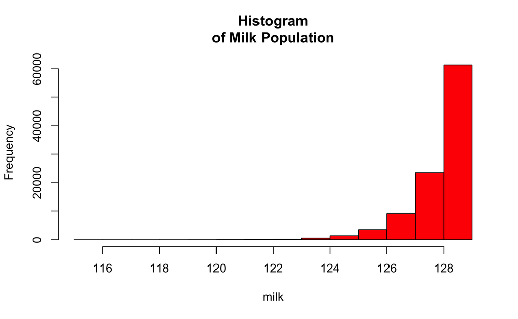

```r
set.seed(343)
milk = 129-rexp(100000,0.95)
hist(milk, main="Histogram
of Milk Population",
col="red")
```

The histogram sample is skewed on the left ( meaning that the data is piled up on the right ).

```r
true_mean = mean(milk)
true_sd = sd(milk)
true_mean
```

```
[1] 127.943
```

```r
true_sd
```

```
[1] 1.058831
```

We can take a sample from our population to see how close we are to the actual true mean.

```r
set.seed(343)
sample_milk <-  sample(milk, size = 50, rep = T)
sample_mean <- mean(sample_milk)
sample_mean
```

```
[1] 127.6673
```

```r
sample_mean - true_mean
```

```
[1] -0.2756964
```

We can calculate the 95% confidence interval for the sample mean in R.

```r
n = 50
sample_milk <-  sample(milk, size = n, rep = T)
sample_mean <- mean(sample_milk)
sample_mean - 1.96 * sd(sample_milk) / sqrt(n)
```

```
[1] 127.7674
```

```r
sample_mean + 1.96 * sd(sample_milk) / sqrt(n)
```

```
[1] 128.3637
```

This is a box plot of our data, with population on the left and sample on the right.

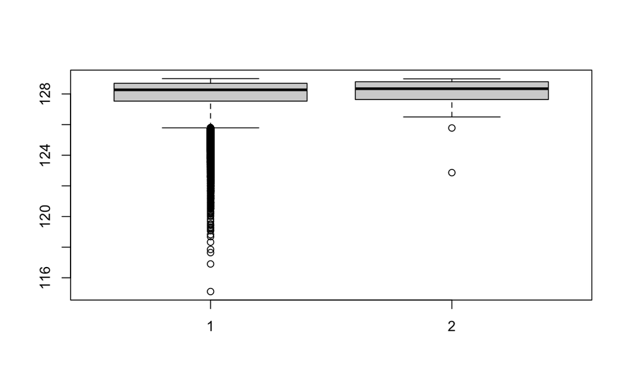

But what might the central limit theorem tell us about this population? Remember, the central limit theorem says that no matter what the shape of the population distribution, the shape of the distribution of sample means is approximately normal.

Suppose that we take 1000 samples of size 𝑛 = 50 and look at the sample distribution.

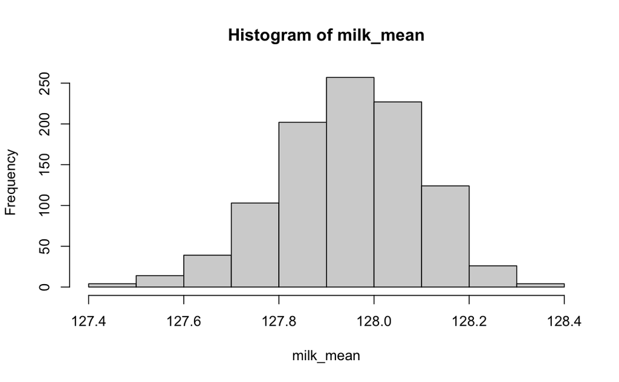

```r
milk_mean <- mapply(\(v) mean(sample(milk, n, rep=T)), 1:1000)


hist(milk_mean)
```

The distribution of sample means looks more like a normal distribution than the distribution of the population.

How normal is the distribution of 1000 sample means? One way to quantify this is to make the normal quantile-quantile ( Q-Q ) plot comparing the quantiles of our distribution against the quantiles of a truly normal distribution.

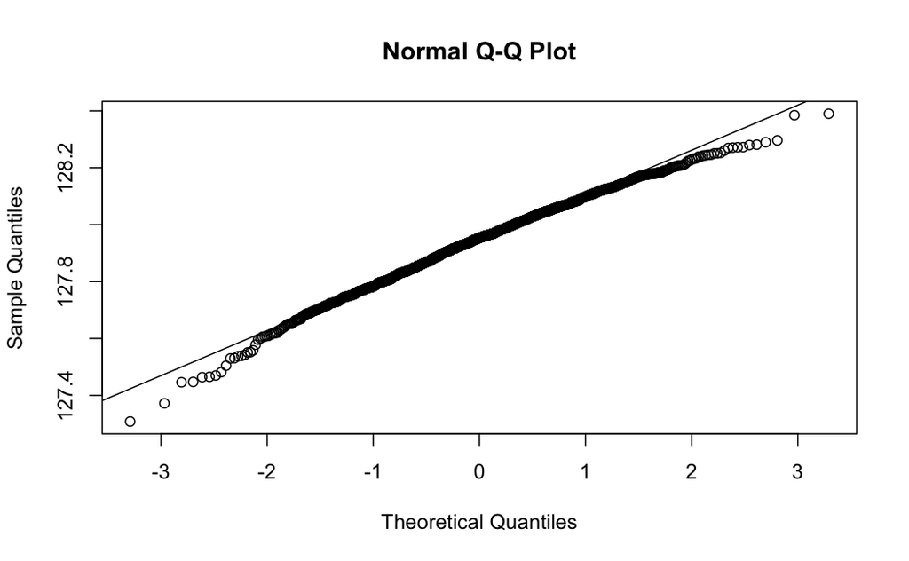

```r
qqnorm(milk_mean)
qqline(milk_mean)
```

We want to compute some confidence intervals from our samples. In this ( artificial ) case, we know the population parameters: μ ( the population mean ) and σ ( the population standard deviation ). We can use R to calculate the confidence intervals.

Now let’s return to our samples of size 𝑛 = 50 and take 100 such samples.

```
Error in hist(samp_mean) + density(samp_mean) :
  non-numeric argument to binary operator
```

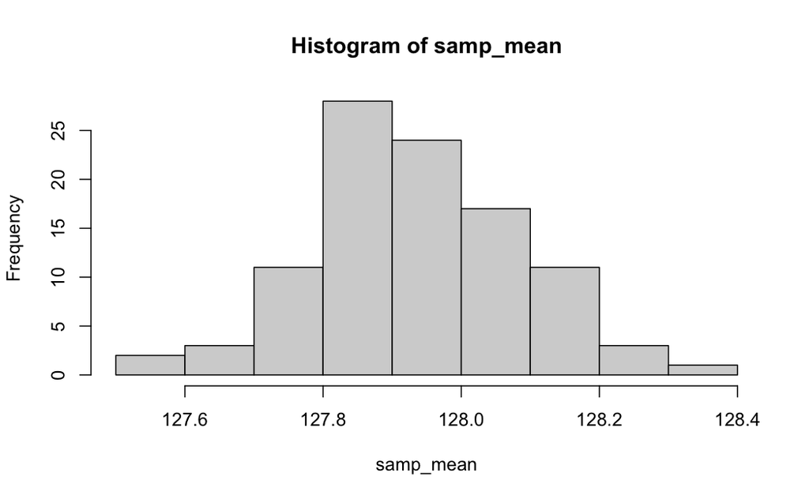

```r
sampe_mean <- mapply(\(v) mean(sample(milk, n, rep=T)), 1:100)
hist(samp_mean) +
density(samp_mean)
```

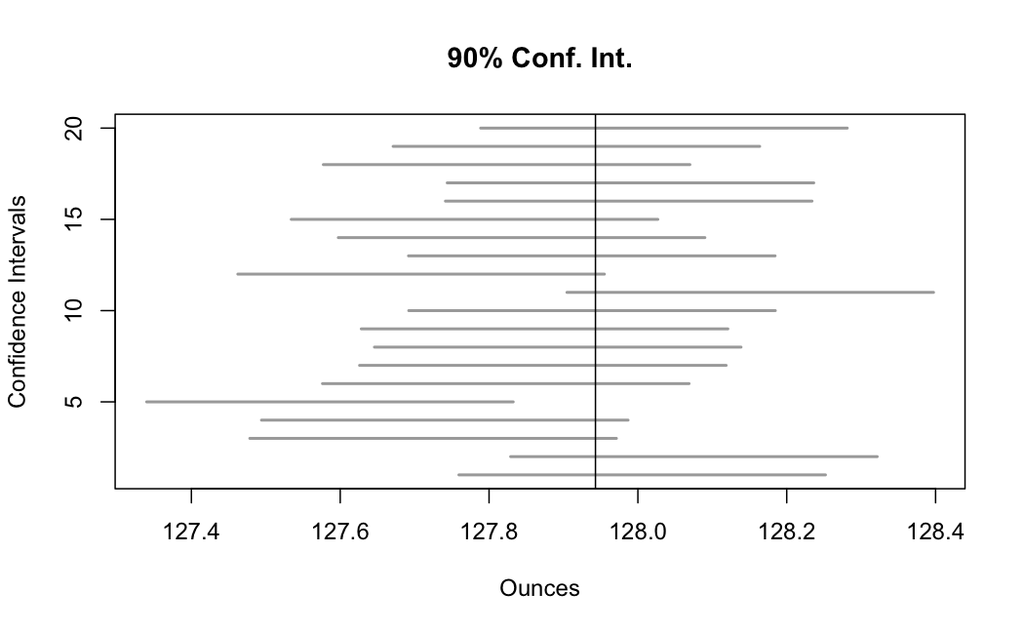

```r
m = 20; n = 50; mu = mean(milk);
sigma = sd(milk);
SE = sigma/sqrt(n)
alpha = 0.10 ; zcrit = qnorm(1-alpha/2);
matplot(rbind(samp_mean[1: m] - zcrit*SE, samp_mean[1: m]
+ zcrit*SE),
rbind(1: m,1: m),
type="l", lty=1,lwd=2,
col='darkgray',
xlab = "Ounces",
ylab="Confidence Intervals",
main="90% Conf. Int.");
abline(v=mu)
```